# Dublin Marathon 2018

Sankhadip Debnath

## Introduction

The Dublin Marathon data consisted of 22 variables on 16433 observations. We decided to remove the variables YouTube, YourRaceVideo and Share as they contained a lot of Na’s and we decided not to use them in our analysis. In part 1 we looked at the top 100 places amongst the categories of groups running. We then looked at the Guntime amongst the different groups. We divided up the categories by gender and looked at the proportion of males and females in each category. In part 2 we looked at the average speed for the first half and last half of the marathon amongst the different running groups. Finally, in part 3 we looked at the proportion of each gender in a club or not and then whether the participants were in a club or not by category. We ran a linear model to see whether being in a club and your age affected on your finishing time.

## The Analysis

PART-1

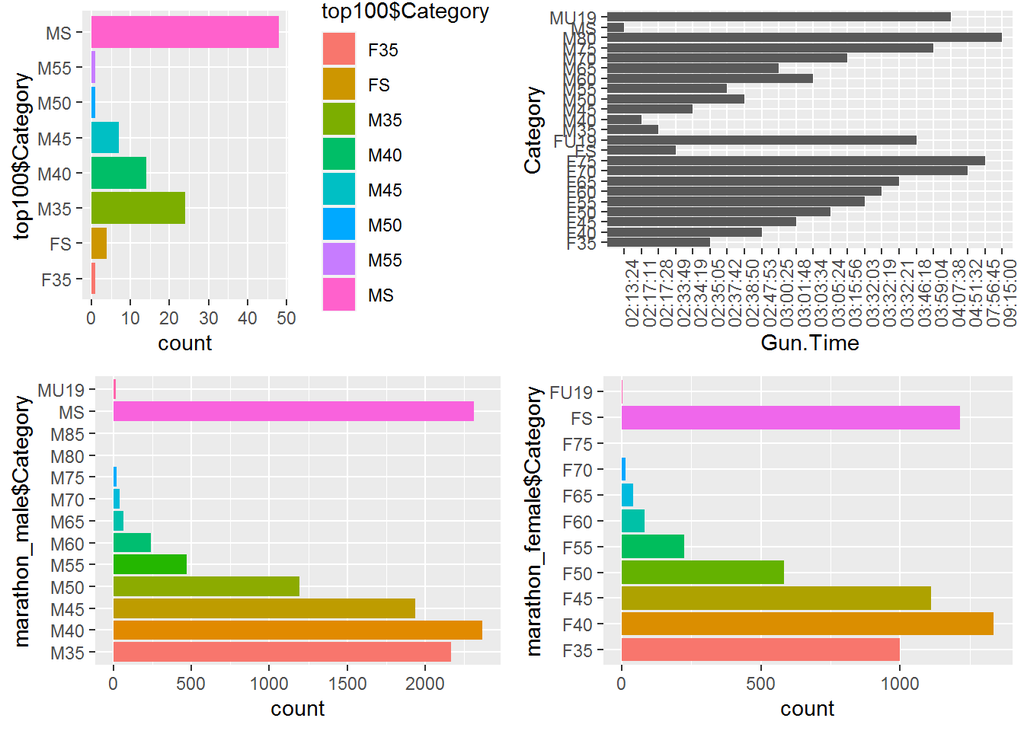

```
##
##  M35  M40  M45  M50  M55  M60  M65  M70  M75  M80  M85   MS MU19
## 2164 2365 1935 1194  470  239   65   40   19    2    1 2315   17
```

```
##
##  F35  F40  F45  F50  F55  F60  F65  F70  F75   FS FU19
##  998 1337 1112  583  225   81   40   13    1 1215    2
```

There were 5607 females and 10826 males competing. In the first graph, we see that the top 100 finishers consisted mostly of category MS. In the second graph, we see that there was a big difference amongst all categories of runners and their gun time. In the bottom two graphs, we see that we have a higher proportion of singles and 40’s for both genders.

PART-2

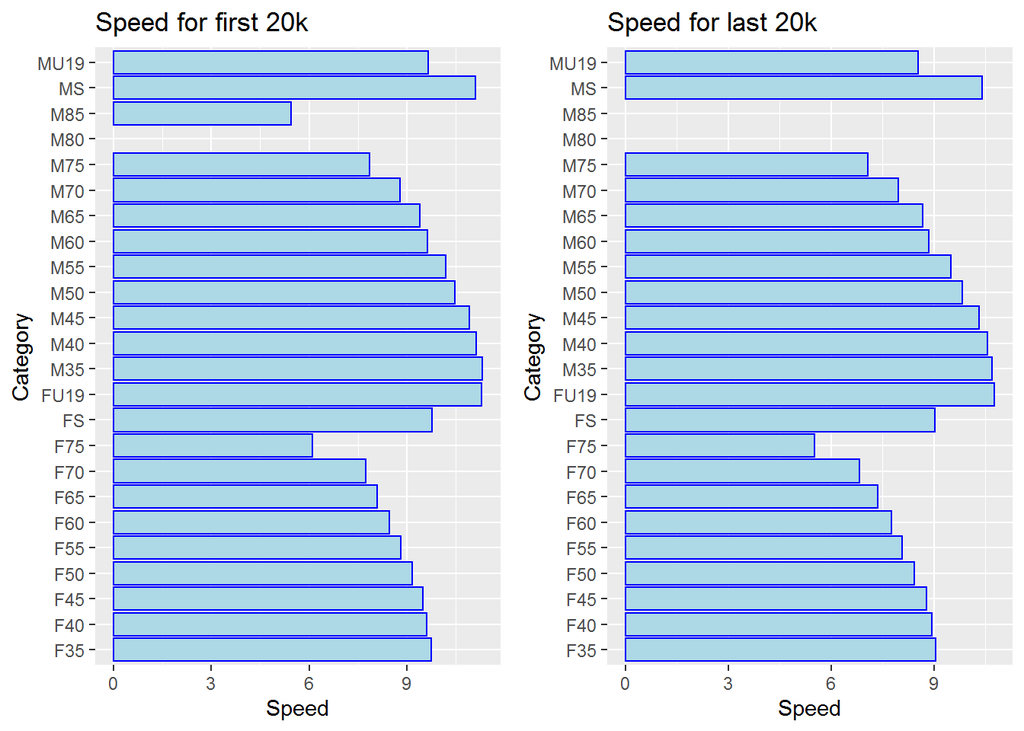

PART-3

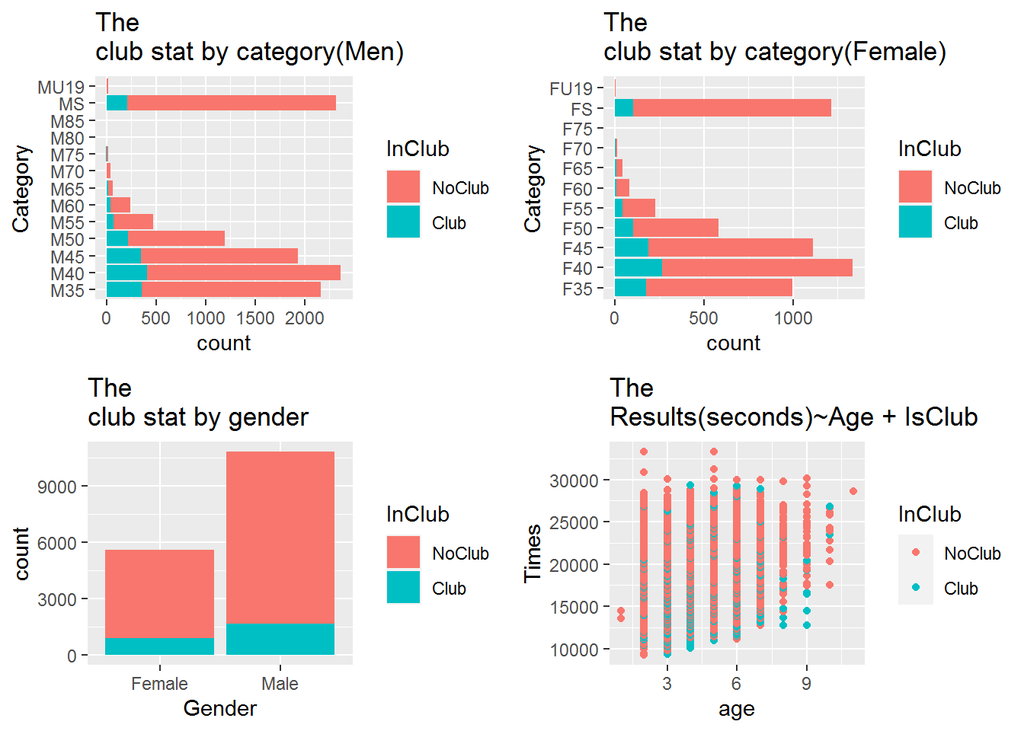

In the first two graphs, we see that the age of 40 groups has the highest number of club participants for both males and females. In the third graph, we see that there are more males in clubs than females, however, there are also more males competing. In the fourth graph, we are looking at the results by age category and participation in a club or not.

```
##                    Estimate   Std. Error      z value     Pr(>|z|)
## (Intercept)     9.749913400 0.0002867519 34001.217026 0.000000e+00
## age             0.023123562 0.0000658744   351.025035 0.000000e+00
## InClubClub     -0.106264411 0.0008433942  -125.996139 0.000000e+00
## age:InClubClub  0.001158442 0.0001867462     6.203295 5.529314e-10
```

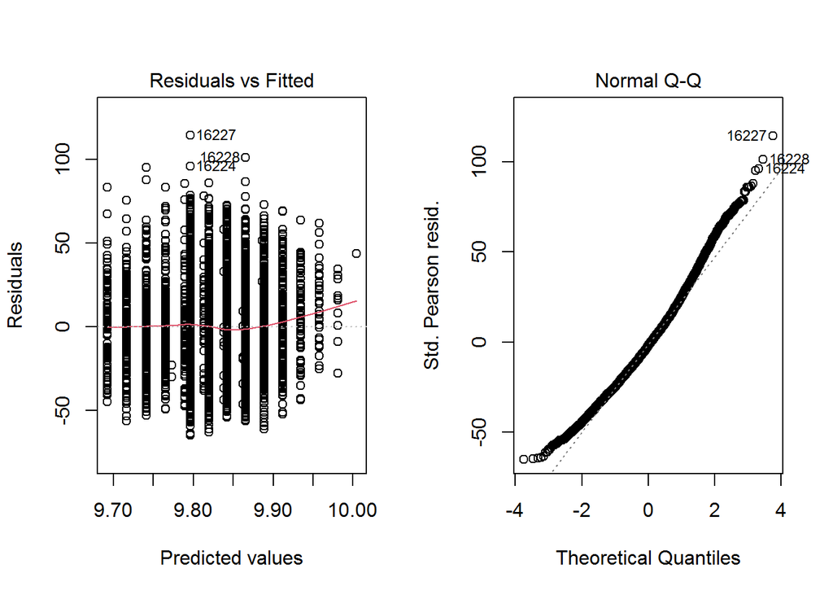

## Conclusion

From the above, we can conclude that twice as many males compete and 95 percent of the top 100 finishers were male. The most popular categories are singles and 40’s aged groups for both genders. Single categorized participants seem to have a better gun time. It was interesting to see the same trend for average speed amongst the categories for the first half and second half of the marathon. We suspected that participation in a club would influence your result. Interestingly there were only 2551(15.5%) participants in a club but the results in the model were still significant.